# Course Project - Practical Machine Learning

Kevin Cole

February 2, 2019

## Course Project - Practical Machine Learning

In this assignment I will be creating a model to predict the way in which a subject is performing a bicep curl based on sensor readings. The data set comes from the *H*uman *A*ctivity *R*esearch (HAR) experiment, which can be found at: http://groupware.les.inf.puc-rio.br/har

## Loading Required Libraries and Setting the Seed

```r
library(caret)
library(randomForest)
```

```r
library(rpart)
library(rpart.plot)
library(rattle)
set.seed("666")
```

## Gathering Data

```r
## Set URLs for data downloads
trainDL <- "http://d396qusza40orc.cloudfront.net/predmachlearn/pml-training.csv"
testDL <- "http://d396qusza40orc.cloudfront.net/predmachlearn/pml-testing.csv"

trainFile <- file.path(getwd(), "pml-training.csv")

## Only download again if not in working directory
if (!file.exists(trainFile)){
    download.file(trainDL, trainFile, method = "curl")
}

testFile <- file.path(getwd(), "pml-testing.csv")

if (!file.exists(testFile)){
    download.file(testDL, testFile, method = "curl")
}

## Read in CSV files, convert NA strings to NAs
training <- read.csv(url(trainDL), na.strings=c("NA","#DIV/0!",""))
testing <- read.csv(url(testDL), na.strings=c("NA","#DIV/0!",""))
```

## Splitting Data

Because we are dealing with a medium-size data set, we will partition the dataset randomly into a training set (60%) and a test set (40%).

```r
inTrain <- createDataPartition(y = training$classe, p = 0.6, list = F)
myTraining <- training[inTrain, ]
myTesting <- training[-inTrain, ]
## Show training and test set dimensions
dim(myTraining)
```

```
## [1] 11776   160
```

```r
dim(myTesting)
```

```
## [1] 7846  160
```

## Cleaning Data

There are a number of variables (columns) with a large percent of NAs, we will remove those columns with more than 60% NAs as they will not serve as helpful predictors.

```r
##Determine number of NAs in Training and Test sets
sumNA_myTraining <- sapply(myTraining, function(df) {sum(is.na(df) == TRUE)/length(df)})
sumNA_myTesting <- sapply(myTesting, function(df) {sum(is.na(df) == TRUE)/length(df)})
## Find those column names where there are more than 60% NAs
trainingColNames <- names(which(sumNA_myTraining < 0.6))
testingColNames <- names(which(sumNA_myTesting < 0.6))
## Remove those columns where there are more than 60% NAs
myTraining <- myTraining[, trainingColNames]
myTesting <- myTesting[, testingColNames]
```

We will also run the function `nearZeroVar()` to determine further variables with little variation, as these will serve as poor predictors.

```r
## Run nearZeroVar on both Training and Test sets
myNZV_Training <- nearZeroVar(myTraining, saveMetrics = T)
myNZV_Testing <- nearZeroVar(myTesting, saveMetrics = T)

## Remove columns with NZV == TRUE
noNZV_Training <- myTraining[, which(myNZV_Training$nzv == F)]
noNZV_Testing <- myTesting[, which(myNZV_Testing$nzv == F)]

## Finally remove columns which are obviously unhelpful (e.g., "x")
myCleanTraining <- noNZV_Training[, c(2:4, 6:59)]
myCleanTesting <- noNZV_Testing[, c(2:4, 6:59)]
```

## Predicting with Random Forests

We’ll try predicting with random forests, as this method requires little tweaking to produce high accuracy.

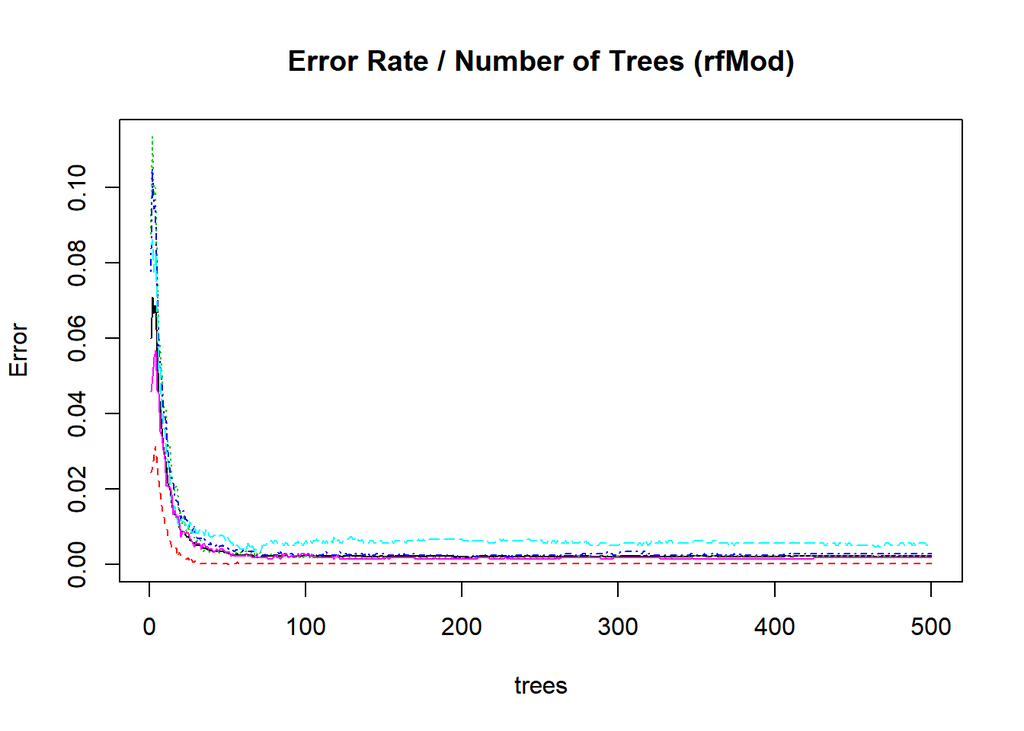

```r
set.seed(666)
## Build the randomForest model to predict classe with all other variables
rfMod <- randomForest(classe ~ ., data = myCleanTraining)
## Predict on the training data
rfTrain <- predict(rfMod, myCleanTraining)
## Save the accuracy of in-sample prediction
rfTrainAcc <- confusionMatrix(myCleanTraining$classe, rfTrain)$overall
plot(rfMod, main = "Error Rate / Number of Trees (rfMod)")
```

```r
## Now predict using our trained model on the testing data
rfTest <- predict(rfMod, myCleanTesting)
## Save and print out-of-sample accuracy
rfTestAcc <- confusionMatrix(myCleanTesting$classe, rfTest)
rfTestAcc
```

```
## Confusion Matrix and Statistics
##
##           Reference
## Prediction    A    B    C    D    E
##          A 2232    0    0    0    0
##          B    2 1516    0    0    0
##          C    0    9 1359    0    0
##          D    0    0    2 1284    0
##          E    0    0    0    2 1440
##
## Overall Statistics
##
##                Accuracy : 0.9981
##                  95% CI : (0.9968, 0.9989)
##     No Information Rate : 0.2847
##     P-Value [Acc > NIR] : < 2.2e-16
##
##                   Kappa : 0.9976
##  Mcnemar's Test P-Value : NA
##
## Statistics by Class:
##
##                      Class: A Class: B Class: C Class: D Class: E
## Sensitivity            0.9991   0.9941   0.9985   0.9984   1.0000
## Specificity            1.0000   0.9997   0.9986   0.9997   0.9997
## Pos Pred Value         1.0000   0.9987   0.9934   0.9984   0.9986
## Neg Pred Value         0.9996   0.9986   0.9997   0.9997   1.0000
## Prevalence             0.2847   0.1944   0.1735   0.1639   0.1835
## Detection Rate         0.2845   0.1932   0.1732   0.1637   0.1835
## Detection Prevalence   0.2845   0.1935   0.1744   0.1639   0.1838
## Balanced Accuracy      0.9996   0.9969   0.9986   0.9991   0.9998
```

**In-Sample Error**

On the training set, the in-sample accuracy was 1, meaning the prediction model was 100% accurate and there is no resubstitution error.

```r
rfTrainAcc[1]
```

```
## Accuracy
##        1
```

**Out-of-Sample Error**

The out-of-sample error rate when applying the prediction model to the test data set was 0.19%, so this is also the predicted out-of-sample error rate.

```r
outOfSampleError.accuracy <- sum(rfTest == myCleanTesting$classe)/length(rfTest)

outOfSampleError.accuracy
```

```
## [1] 0.9980882
```

```r
outOfSampleError <- 1 - outOfSampleError.accuracy
paste0("Out of Sample Error: ", round((outOfSampleError * 100), 2),  "%")
```

```
## [1] "Out of Sample Error: 0.19%"
```

## Quiz: Predicting Cases

Now we’ll see how the prediction model fares on the quiz samples.

```r
## Read in test cases for quiz
quiz <-read.csv(testFile, header=T, sep=",", na.strings=c("NA","#DIV/0!"))
## Predict using our randomForests model
predquiz <- predict(rfMod, quiz)
names(predquiz) <- c(1:20)
## Print predictions
predquiz
```

```
##  1  2  3  4  5  6  7  8  9 10 11 12 13 14 15 16 17 18 19 20
##  B  A  B  A  A  E  D  B  A  A  B  C  B  A  E  E  A  B  B  B
## Levels: A B C D E
```

```r
## Write answers to text files for upload
path <- file.path(getwd(), "Practical_Machine_Learning/Quiz")
pml_write_files = function (x){
        n = length(x)
        for(i in 1:n) {
                filename = paste0("problem_id_",i,".txt")
                write.table(x[i],file=file.path(path, filename),quote=FALSE,row.names=FALSE,col.names=FALSE)
        }
}
pml_write_files(predquiz)
```